# Project 1

Molly Sledz

2025-10-10

## Introduction

I’d like to answer “how big of a different are the sales in games for European gamers compared to North American gamers?” as well as “Which publisher has taken over many of the gaming platforms?”.

[figure not shown]

Wii Sports from Wikipedia (https://en.wikipedia.org/wiki/Wii_Sports)

## Variable Descriptions

| Name | Type | Discription |
| --- | --- | --- |
| Rank | double | Ranking of overall sales |
| Name | character | The games name |
| Platform | character | Platform of the games release |
| Year | character | Year of the game’s release |
| Genre | character | Genre of the game |
| Publisher | character | Publisher of the game |
| NA_Sales | double | Sales in North America (in millions) |
| EU_Sales | double | Sales in Europe (in millions) |
| JP_Sales | double | Sales in Japan (in millions) |
| Other_Sales | double | Sales in the rest of the world (in millions) |
| Global_Sales | double | Total worldwide sales(in millions) |
| Age | double | How old the game is in 2025 |
| CompanyOrigin | character | Company Origin |

## Univariate Analyses:

### The Count of Video Game Platforms

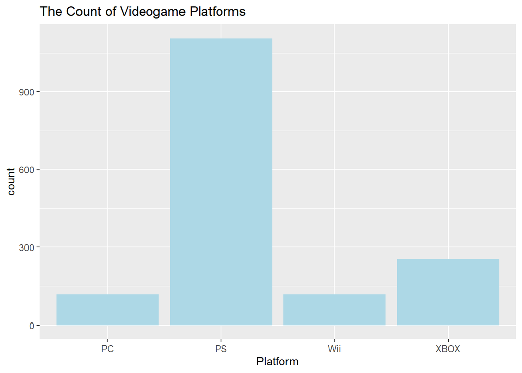

```
##
##   PC   PS  Wii XBOX
##  118 1106  117  254
```

There are 118 PC games, 1106 PlayStation games, 117 Wii games, and 254 Xbox games in this data set.

### The Count of Video Game Publishers

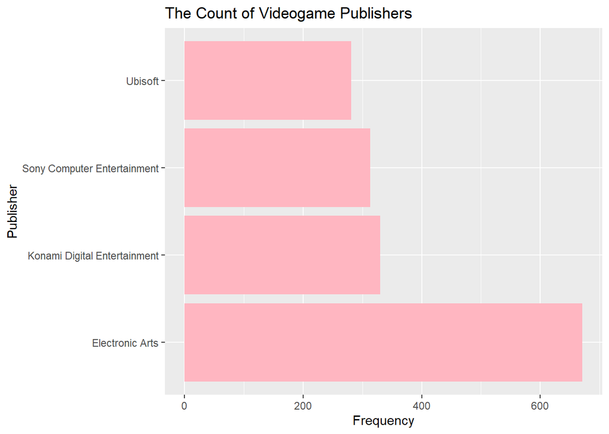

```
##
##              Electronic Arts Konami Digital Entertainment
##                          671                          330
##  Sony Computer Entertainment                      Ubisoft
##                          313                          281
```

There are 671 Electronic Arts games, 313 Sony Computer Entertainment games, 330 Konami Digital Entertainment games, and 281 Ubisoft games.

### The Count of Video Game Ages

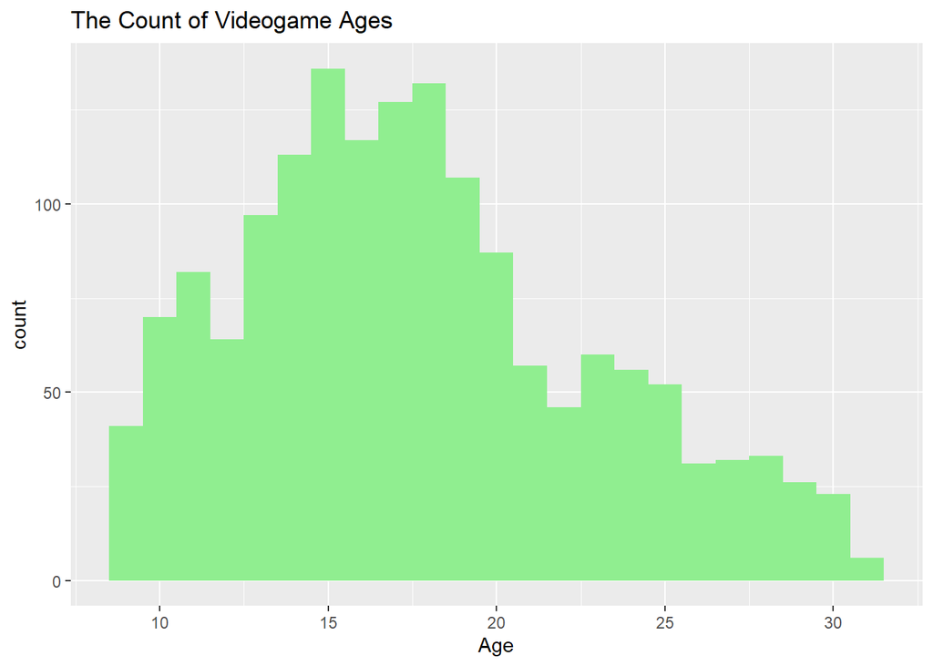

The median age for video games is 17 and the IQR is 7.

### The Count of Company Country Origin

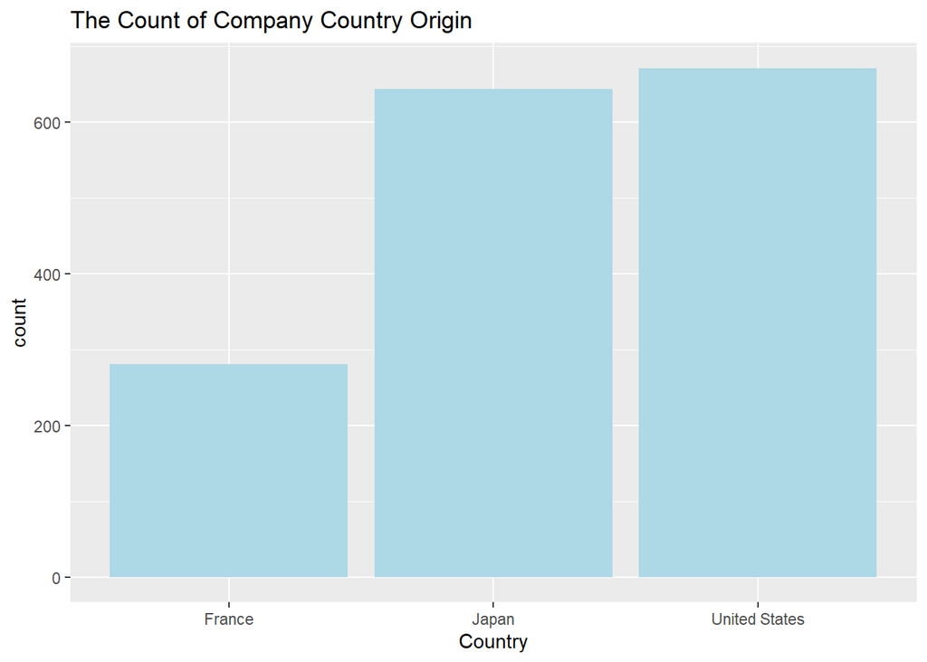

```
##
##        France         Japan United States
##           281           643           671
```

### The Count of Video Game Genre

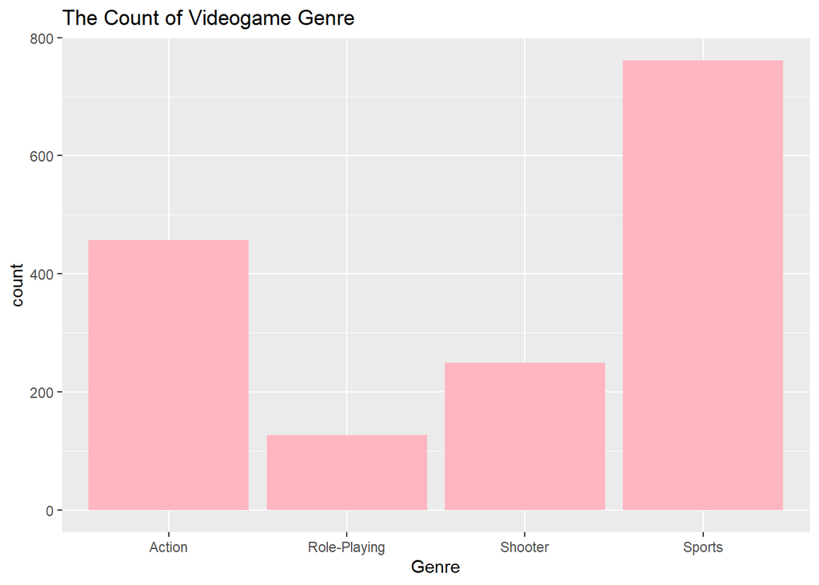

```
##
##       Action Role-Playing      Shooter       Sports
##          457          127          249          762
```

In this data set, there are 457 action games, 127 role-playing games, 249 shooter games, and 762 sports games.

## Bivariate Analyses:

### European Sales of Games Versus North American Sales

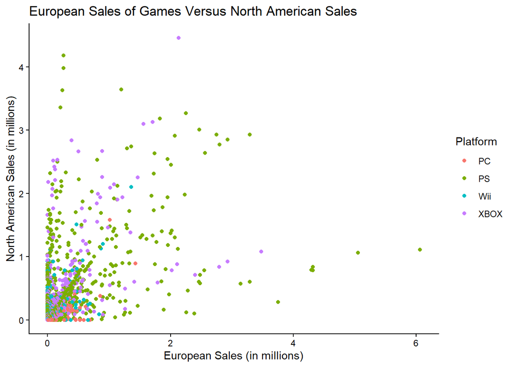

The graph of European Sales versus North American Sales of video games has a moderate positive correlation and an correlation coefficient of 0.48. As the European sales increase, the American sales also increase.

### Rank Versus Global Sales

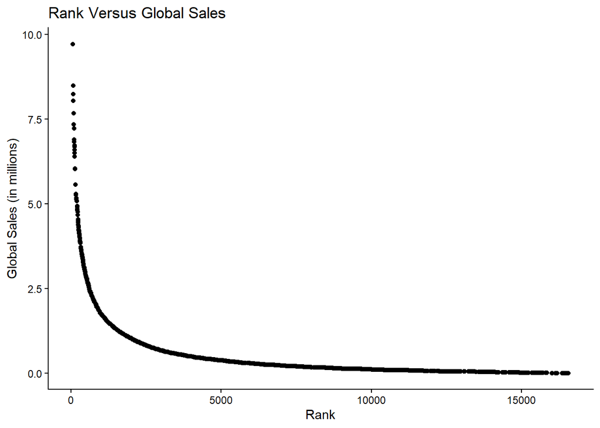

### Age Versus Global Sales

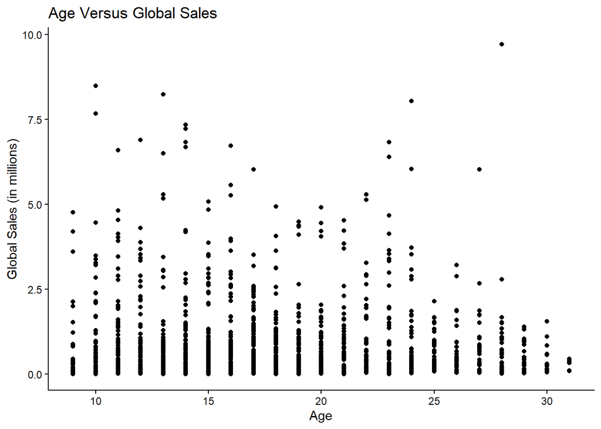

The graph of Age versus Global Sales of video games has a very weak postive correlation and an correlation coefficient of 0.06. As the age increases, the global sales increase.

### Publisher by Platform

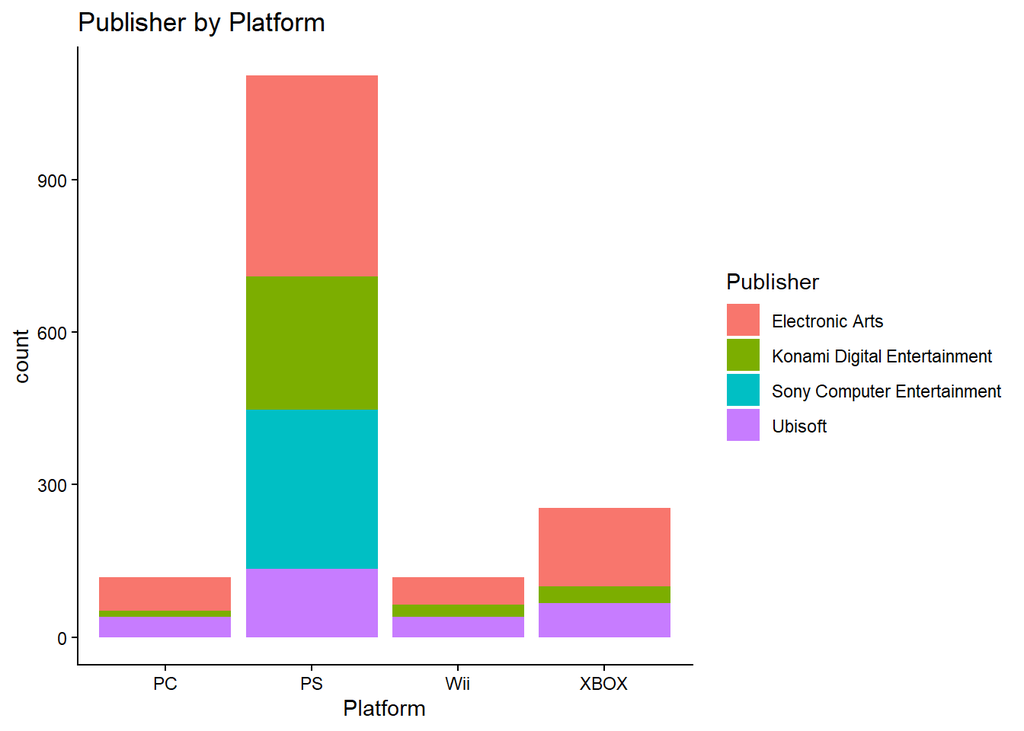

```
##
##        Electronic Arts Konami Digital Entertainment Sony Computer Entertainment
##   PC                66                           12                           0
##   PS               397                          262                         313
##   Wii               53                           24                           0
##   XBOX             155                           32                           0
##
##        Ubisoft
##   PC        40
##   PS       134
##   Wii       40
##   XBOX      67
```

Electronic Arts (EA), Sony Computer Entertainment, Konami Digital Entertainment, and Ubisoft have the most games on PlayStation. Sony only has games on the PlayStation while EA has over 150 games on Xbox.

## Choice Elements:

I created two new variables (age and company origin) by subtracting the year it was released to 2025 as well as googling the company origin of the publishers. I also parsed the string variable Year into a number for the age variable. I added a floating table of contents to the top left. I also added 5 or more in-line codes in my report as the descriptions of the graphs have a in line numeric values. I made the graph section titles smaller than the main section titles so that on the table of contents, it allows user to go to the main section and the subsections. I have changed the font style, size, and color.

## Conclusion:

Answering my 1st research question, there isn’t too large of a different because as European gamers buy games, North American gamers are also buying games. For my second question, EA has the most games on PlayStation but Sony only has games on PlayStation. EA has the most games on all platforms. I have also noticed that the genre with the most games is sports games while the genre with the least is role-playing games. The median age for a video game in the data set is 17 years with an IQR of 7 years. One future area of research could be finding player counts within the first year because many games could have high sales but differing player counts or average player game time.

## References:

Zenodo.org for data scraping

vgchartz.com for the data collection

Google Gemini (https://gemini.google.com) for explanation of font options using a CSS code chuck

Sage AI (https://sage.eta.its.utexas.edu/) for show_col_types = FALSE so that the warning message wouldn’t show